# Project 1

Qingyang Zhong (qz2317)

9/19/2018

# Part 1: Preprocess

Firstly, we need to process the raw textual data preparing for the analysis, which has been done by the starter code provided by Prof.Tian.

## Step 0: Load packages

```r
packages.used=c("plyr","tm","tidytext","tidyverse","DT","wordcloud","scales","wordcloud2","gplots","ngram","dplyr","qdap","syuzhet","ggplot2","topicmodels","gridExtra","shiny","igraph","text2vec","data.table","magrittr","glmnet","reshape")

# check packages that need to be installed.
packages.needed=setdiff(packages.used,
                        intersect(installed.packages()[,1],
                                  packages.used))
# install additional packages
if(length(packages.needed)>0){
  install.packages(packages.needed, dependencies = TRUE)
}

library(tidyverse)
library(tidytext)
library(DT)
library(scales)
library(wordcloud)
library(gridExtra)
library(ngram)
library(shiny)
library(ggplot2)
library(plyr)
library(dplyr)
library(tm)
library(igraph)
library(text2vec)
library(data.table)
library(magrittr)
library(glmnet)
library(wordcloud2)
library(topicmodels)
library(gplots)
library(reshape)
```

## Step 1: Load processed data along with demographic information on contributors and combine them

```r
hm_data <- read_csv("../output/processed_moments.csv")

urlfile<-'https://raw.githubusercontent.com/rit-public/HappyDB/master/happydb/data/demographic.csv'
demo_data <- read_csv(urlfile)

hm_data <- hm_data %>%
  inner_join(demo_data, by = "wid") %>%
  select(wid,
         original_hm,
         gender,
         marital,
         parenthood,
         reflection_period,
         age,
         country,
         ground_truth_category,
         text) %>%
  mutate(count = sapply(hm_data$text, wordcount)) %>%
  filter(gender %in% c("m", "f")) %>%
  filter(marital %in% c("single", "married")) %>%
  filter(parenthood %in% c("n", "y")) %>%
  filter(reflection_period %in% c("24h", "3m")) %>%
  mutate(reflection_period = fct_recode(reflection_period,
                                        months_3 = "3m", hours_24 = "24h"))
```

# Part 2: Key words

In this section, firstly we will find out the key words about these moment.

## Step 1: Create a word cloud with top 200 key words.

```r
wordcount <- hm_data$text %>%
  str_trim() %>%
  lapply(strsplit," ") %>%
  unlist() %>%
  table() %>%
  as.data.frame()

colnames(wordcount) <- c("Keyword","Freq")

sorted <- wordcount %>% dplyr::arrange(desc(Freq))

png(filename = ".../output/wordcloud.png")

wordcloud2(sorted[1:200,],color = "random-light", size = 0.5,shape = "circle")
```

[interactive chart not shown]

```r
dev.off()
```

## Step 2: Show the frequency of the top 50 key words in bar chart.

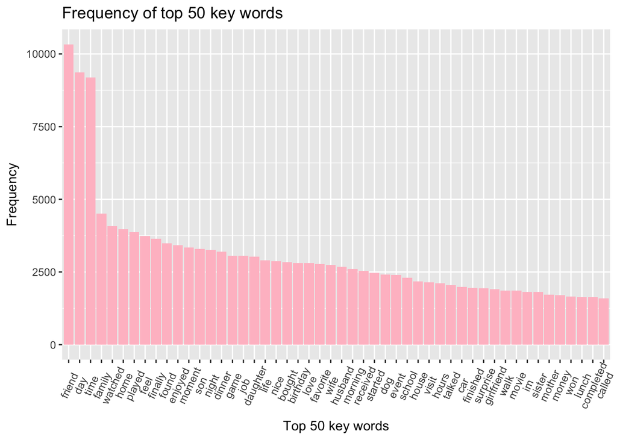

```r
keywords50 <- head(sorted, n=50)

ggplot(keywords50,aes(fill=keywords50$Keyword)) +
  geom_bar(aes(x=keywords50$Keyword,y=keywords50$Freq),stat='identity',fill="pink")+
  xlab('Top 50 key words')+
  ylab('Frequency')+
  ggtitle('Frequency of top 50 key words')+
  theme(axis.text.x = element_text(angle=65, vjust=0.6)) +
  scale_x_discrete(limits= keywords50$Keyword) +
  guides(fill=FALSE)
```

We can find that from both graphs above, the frequent key words come up in these moment are related to friend and family.

## Step 3: LDA

```r
dtm <- VCorpus(VectorSource(hm_data$text)) %>%DocumentTermMatrix()
rowTotals <- slam::row_sums(dtm)
dtm <- dtm[rowTotals > 0, ]

#Number of topics
k <- 10

#Run LDA using Gibbs sampling
ldaOut <- LDA(dtm, k, method="Gibbs", control=list(nstart=5, seed = list(2003,5,63,100001,765), best=TRUE, burnin = 800, iter = 400, thin=100))

Out <- as.matrix(topics(ldaOut))

# Total number per each topic
table(c(1:k, Out))
```

```
##
##     1     2     3     4     5     6     7     8     9    10
## 14682 13067 10135 11746  9289  6767  9453  9049  6899  3483
```

```r
#top 10 terms in each topic
ldaOut.terms <- as.matrix(terms(ldaOut,10))
ldaOut.terms
```

```
##       Topic 1      Topic 2   Topic 3   Topic 4     Topic 5      Topic 6
##  [1,] "day"        "morning" "time"    "job"       "friend"     "moment"
##  [2,] "daughter"   "dog"     "family"  "received"  "talked"     "day"
##  [3,] "birthday"   "nice"    "enjoyed" "money"     "girlfriend" "event"
##  [4,] "love"       "walk"    "visit"   "called"    "won"        "school"
##  [5,] "surprise"   "night"   "home"    "promotion" "met"        "life"
##  [6,] "brother"    "cat"     "spend"   "pay"       "fun"        "son"
##  [7,] "sister"     "sleep"   "day"     "card"      "meet"       "college"
##  [8,] "mother"     "park"    "trip"    "company"   "hours"      "class"
##  [9,] "celebrated" "woke"    "weekend" "told"      "team"       "excited"
## [10,] "mom"        "relax"   "kids"    "expected"  "girl"       "passed"
##       Topic 7     Topic 8    Topic 9     Topic 10
##  [1,] "watched"   "dinner"   "finally"   "feel"
##  [2,] "played"    "wife"     "car"       "happiness"
##  [3,] "found"     "husband"  "finished"  "people"
##  [4,] "game"      "home"     "house"     "live"
##  [5,] "bought"    "favorite" "started"   "person"
##  [6,] "movie"     "night"    "completed" "makes"
##  [7,] "shopping"  "lunch"    "weeks"     "life"
##  [8,] "video"     "food"     "helped"    "positive"
##  [9,] "purchased" "eat"      "project"   "experience"
## [10,] "buy"       "ate"      "moved"     "joy"
```

# Part 3: Analysis Regarding Nationality

## Step 1: Omit the data points that are not having country information

```r
hm_data <- hm_data[!is.na(hm_data$country),]
```

## Step 2: Find the distribution about nationality in this dataset

```r
count(hm_data$country)[count(hm_data$country)$freq>500,]
```

|  | x | freq |
| --- | --- | --- |
| 15 | CAN | 531 |
| 40 | IND | 16629 |
| 94 | USA | 73475 |
| 95 | VEN | 546 |

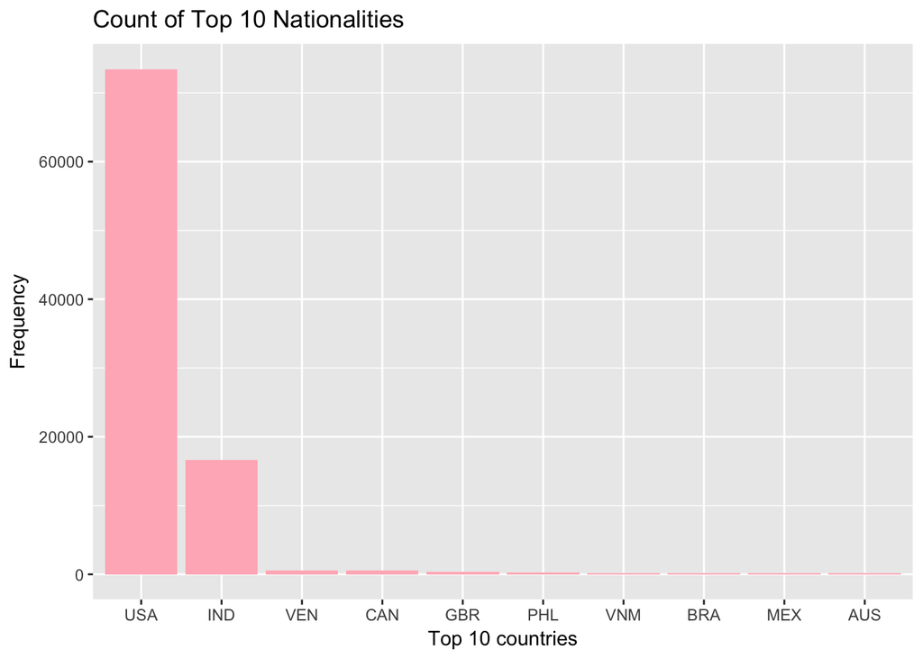

```r
country<-as.data.frame(table(hm_data$country))
sortcountry<-country %>% dplyr::arrange(desc(Freq))
sortcountry<-head(sortcountry,n=10)
ggplot(sortcountry,aes(fill=sortcountry$Var1)) +
  geom_bar(aes(x=sortcountry$Var1,y=sortcountry$Freq),stat='identity',fill="lightpink")+
  xlab('Top 10 countries')+
  ylab('Frequency')+
  ggtitle('Count of Top 10 Nationalities')+
  scale_x_discrete(limits= sortcountry$Var1) +
  guides(fill=FALSE)
```

We can see that the marjority is from USA and IND, so we are going to do some comparison between these 2 countries. And see if nationality plays a part in happy moments.

## Step 3: Frequency of keywords in USA and India

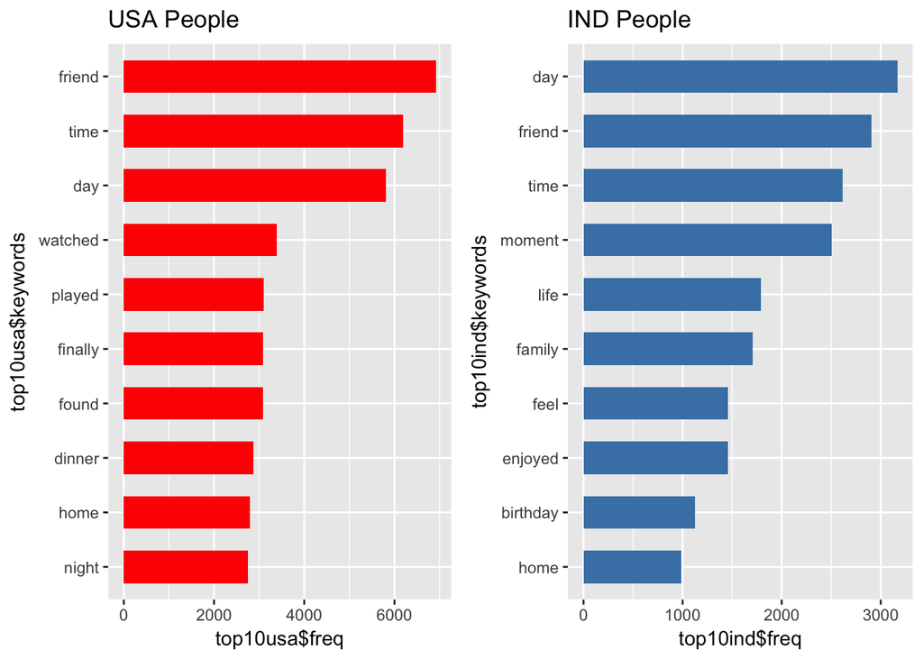

```r
usa <- hm_data[which(hm_data$country=="USA"),]
usa_word <- usa$text %>%
  str_trim() %>%
  lapply(strsplit," ") %>%
  unlist() %>%
  table() %>%
  as.data.frame() %>%
  dplyr::arrange(desc(Freq))

ind <- hm_data[which(hm_data$country=="IND"),]
ind_word <- ind$text %>%
  str_trim() %>%
  lapply(strsplit," ") %>%
  unlist() %>%
  table() %>%
  as.data.frame() %>%
  dplyr::arrange(desc(Freq))

top10usa<-  usa_word[1:10,]

names(top10usa) <- c("keywords","freq")

g_usa<-ggplot(top10usa) + geom_bar(aes(x=top10usa$keywords,y=top10usa$freq),
        position="dodge",stat="identity",
        width=0.6,fill="red")+
        scale_x_discrete(limits= rev(top10usa$keywords))+
        guides(fill=F)+
        ggtitle("USA People")+
        coord_flip()

top10ind<- ind_word[1:10,]

names(top10ind) <- c("keywords","freq")

g_ind<-ggplot(top10ind) + geom_bar(aes(x=top10ind$keywords,y=top10ind$freq),
        position="dodge",stat="identity",
        width=0.6,fill="steelblue")+
        scale_x_discrete(limits= rev(top10ind$keywords))+
        guides(fill=F)+
        ggtitle("IND People")+
        coord_flip()

grid.arrange(g_usa,g_ind,ncol=2,nrow=1)
```

From the chart above shows the frequent words used by USA and IND.

## Step 4: Comparation between key words of USA and India

A comparison cloud compares the relative frequency with which a term was used in two or more groups and it plots the difference between the word usage in the documents.

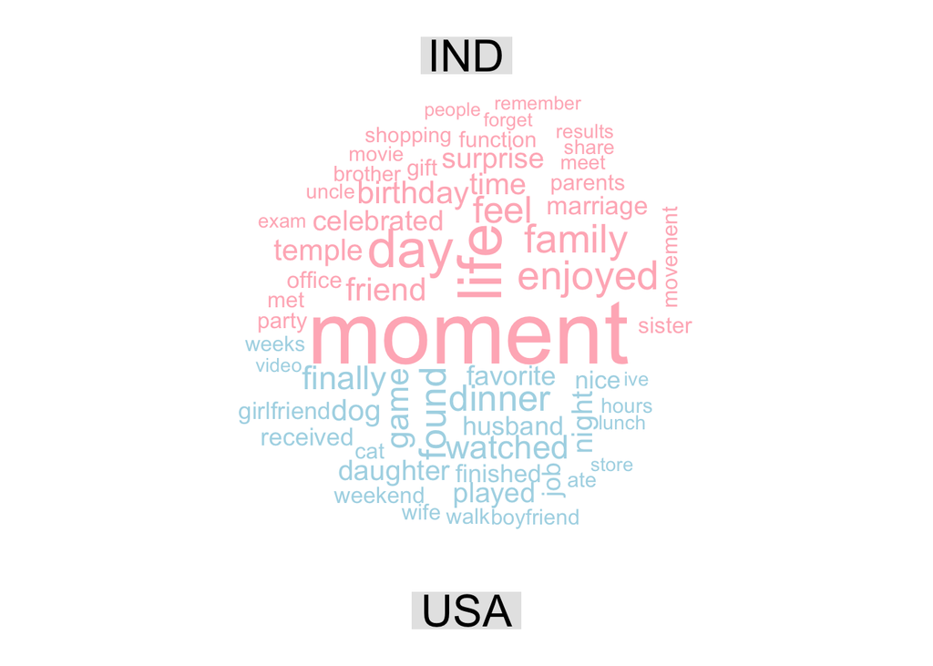

```r
hm_data_country<-hm_data[hm_data$country=='USA'|hm_data$country=='IND',]

bag_of_words <-  hm_data_country %>% unnest_tokens(word, text)

wordcount2 <- bag_of_words %>%group_by(country)%>%dplyr::count(word, sort = TRUE)

tdm2 <- cast(wordcount2,word~country,value = 'n')
tdm2[is.na(tdm2)] <- 0
rownames(tdm2) <- tdm2$word
tdm2$word <- NULL

comparison.cloud(tdm2, random.order=FALSE,colors=c('lightpink','lightblue'),
                 title.size=2, max.words=60)
```

From the comparison cloud, we can see that words like ‘life’ and ‘day’ were more front-and-center in India than in USA. While ‘watched’, ‘dog’ is large in the USA side.